# Should diverticulitis be considered a qualifying weight related comorbidity for bariatric surgery?

true , Dylan Russell, M.D. https://www.github.com/dylanrussellmd (Tripler Army Medical Center) , Scott H. Nguyen, M.D. (Tripler Army Medical Center) , Christopher Yheulon, M.D. (Tripler Army Medical Center, Emory University)

“June 25, 2022”

# Abstract

**Introduction**: With rising obesity rates, surgeons are operating on increasingly larger patients. Minimally invasive surgery has helped ease this burden on surgeons. However, we are still quantifying the impact of weight on surgical outcomes. The purpose of this study is to determine the role of obesity in elective laparoscopic colectomy for colonic diverticulitis.

# Introduction

Diverticulitis is an increasingly common clinical entity encountered in surgical practice, both in the inpatient and outpatient settings [1–3]. The disease accounts for approximately 200,000 annual hospital admissions, almost one million total hospital days and two billion dollars in aggregate costs to the healthcare system [4, 5]. It affects predominantly the sigmoid colon in Western nations and its incidence is growing, with growth occurring among younger age groups. This shift in demographical disease burden results in an out-sized impact on societal productivity loss, economic impact, morbidity and mortality [1, 3, 6, 7].

Management of diverticulitis was classically based on number of symptomatic disease flares. Treatment was primarily supportive; bowel rest and antibiotics being the pillars of accepted dogma [8]. After a set number of episodes, patients were counseled to undergo open or laparoscopic colectomy after resolution of acute inflammation [2, 9].

This treatment paradigm has started to shift. New data and recent clinical guidelines no longer recommend surgery after a prescribed number of episodes [10, 11]. Current recommendations are pragmatically more patient centered, with surgery contingent on the patient’s perceived impact of the disease on their quality of life. Furthermore, patients with uncomplicated diverticulitis are now being treated on an outpatient basis and without need for antibiotics. This shift has further pushed the management of diverticular disease towards a truly elective surgical intervention.

There is growing evidence linking obesity to diverticulosis, severity and complications related to diverticular disease, and worse outcomes after surgery [12–19]. However, diverticular disease is not considered a weight related comorbidity to qualify for bariatric surgery [20–22]. Therefore, we aim to explore the rates of adverse surgical outcomes in obese patients compared to matched non-obese patients. We hypothesize that that bariatric surgery prior to colectomy could be a reasonable risk reduction strategy.

# Methods

## Data Source and Study Population

Data was obtained from the American College of Surgeons National Surgical Quality Improvement Program (ACS-NSQIP) targeted colectomy database. As the ACS-NSQIP database is de-identified and publicly available, institutional review board approval was not required. The database was queried for patients with a body mass index (BMI) less than 30 (non-obese) or between 35-40 (obese) undergoing elective, non-emergent, minimally invasive partial colectomy with or without primary anastomosis for an indication of diverticular disease from 2012-2019. Included CPT codes were 44140, 44141, 44143-44146, 44204, and 44206-44208. Patients with a BMI over 40 were excluded as these patients would have already met criteria for bariatric surgery. Patients with diabetes, ascites, a history of congestive heart failure or myocardial infarction, and hypertension requiring medical management were excluded as these would be considered a weight related comorbidity that would meet criteria for bariatric surgery. Patients with disseminated cancer, ventilator support, pre-operative sepsis, Association of Anesthesia classification 5, or incomplete data were also excluded.

## Outcomes

The outcomes of interest included anastomotic leak, conversion to open, colostomy or ileostomy construction, overall surgical site infections (SSI), superficial SSI, deep SSI, organ-space SSI, readmission, reoperation, operative time, and length of stay.

## Statistical Analysis

Computations were performed with R version 4.2.0 (2022-04-22) [23]. A 2:1 propensity scored nearest neighbor match was performed. Patients with a BMI less than 30 were matched against patients with a BMI between 35 and 40. Patients were matched for age, sex, smoking status, functional status, history of COPD, history of steroid use, pre-operative weight loss >10%, bleeding disorders, and ASA class. A covariate balance assessment was performed using the standardized mean difference (SMD) with an SMD > 0.1 considered unbalanced. A post-weighting balance assessment was performed to ensure an optimal balance. Outcomes were compared both before and after matching. Binomial outcomes were reported as rates and hypothesis testing conducted with a standard test for binomial proportions. Continuous outcomes were reported as means with hypothesis testing conducted with a two-sample t-test. A p-value of 0.05 or less was considered significant.

# Results

Table 1: Pre-match balance assessment

|  | BMI <30 | BMI 35-40 | SMD |
| --- | --- | --- | --- |
| n | 1954 | 263 |  |
| Male (%) = TRUE | 931 (47.6) | 120 ( 45.6) | 0.040 |
| Age (mean (SD)) | 56.12 (11.54) | 47.60 (11.37) | 0.743 |
| Smoking history (%) = TRUE | 374 (19.1) | 50 ( 19.0) | 0.003 |
| Functionally independent (%) |  |  | 0.056 |
| Independent | 1934 (99.8) | 262 (100.0) |  |
| Partially dependent | 2 ( 0.1) | 0 ( 0.0) |  |
| Totally dependent | 1 ( 0.1) | 0 ( 0.0) |  |
| History of COPD (%) = TRUE | 40 ( 2.0) | 3 ( 1.1) | 0.072 |
| Steroid use (%) = TRUE | 51 ( 2.6) | 8 ( 3.0) | 0.026 |
| >10% weight loss (%) = TRUE | 48 ( 2.5) | 0 ( 0.0) | 0.224 |
| Bleeding disorder (%) = TRUE | 13 ( 0.7) | 2 ( 0.8) | 0.011 |
| Preoperative transfusion (%) = TRUE | 1 ( 0.1) | 0 ( 0.0) | 0.032 |
| ASA class (%) |  |  | 0.439 |
| 1 | 133 ( 6.8) | 5 ( 1.9) |  |
| 2 | 1456 (74.5) | 164 ( 62.4) |  |
| 3 | 360 (18.4) | 93 ( 35.4) |  |
| 4 | 5 ( 0.3) | 1 ( 0.4) |  |
| 5 | 0 ( 0.0) | 0 ( 0.0) |  |

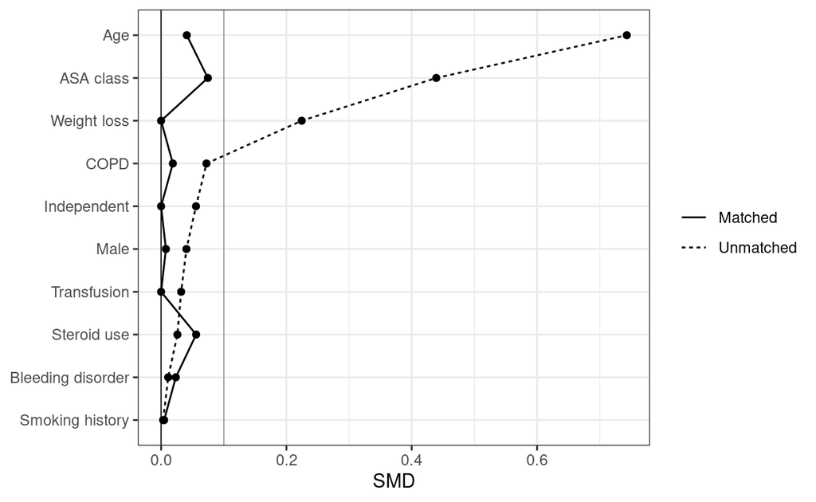

Figure 1: Pre- and post-match balance assessment

Table 2: Post-match discrete outcomes

| Outcome | Group | N | Missing | Events | Rate (%) | Difference (%) | 95% CI | p |
| --- | --- | --- | --- | --- | --- | --- | --- | --- |
| Anastomotic Leak |  |  |  |  |  |  |  |  |
|  | BMI <30 | 522 | 0 | 14 | 2.68 |  |  |  |
|  | BMI 35-40 | 261 | 0 | 13 | 4.98 | -2.3 | -5.28 to 0.68 | 0.097 |
| Conversion |  |  |  |  |  |  |  |  |
|  | BMI <30 | 522 | 0 | 37 | 7.09 |  |  |  |
|  | BMI 35-40 | 261 | 0 | 30 | 11.49 | -4.4 | -8.86 to 0.05 | 0.038 |
| Ostomy |  |  |  |  |  |  |  |  |
|  | BMI <30 | 522 | 0 | 16 | 3.07 |  |  |  |
|  | BMI 35-40 | 261 | 0 | 8 | 3.07 | 0 | -2.56 to 2.56 | 1.000 |
| Overall SSI |  |  |  |  |  |  |  |  |
|  | BMI <30 | 522 | 0 | 29 | 5.56 |  |  |  |
|  | BMI 35-40 | 261 | 0 | 18 | 6.90 | -1.34 | -4.99 to 2.31 | 0.456 |
| Superficial SSI |  |  |  |  |  |  |  |  |
|  | BMI <30 | 522 | 0 | 8 | 1.53 |  |  |  |
|  | BMI 35-40 | 261 | 0 | 4 | 1.53 | 0 | -1.83 to 1.83 | 1.000 |
| Deep SSI |  |  |  |  |  |  |  |  |
|  | BMI <30 | 522 | 0 | 2 | 0.38 |  |  |  |
|  | BMI 35-40 | 261 | 0 | 2 | 0.77 | -0.39 | -1.57 to 0.8 | 0.478 |
| Organ-space SSI |  |  |  |  |  |  |  |  |
|  | BMI <30 | 522 | 0 | 20 | 3.83 |  |  |  |
|  | BMI 35-40 | 261 | 0 | 14 | 5.36 | -1.53 | -4.72 to 1.66 | 0.321 |
| Readmission |  |  |  |  |  |  |  |  |
|  | BMI <30 | 522 | 0 | 19 | 3.64 |  |  |  |
|  | BMI 35-40 | 261 | 0 | 19 | 7.28 | -3.64 | -7.18 to -0.1 | 0.025 |
| Reoperation |  |  |  |  |  |  |  |  |
|  | BMI <30 | 522 | 0 | 15 | 2.87 |  |  |  |
|  | BMI 35-40 | 261 | 0 | 12 | 4.60 | -1.73 | -4.64 to 1.19 | 0.213 |

Table 3: Post-match continuous outcomes

| Outcome | Group | N | Missing | Mean | Lower SD | Upper SD | Mean difference | 95% CI | p |
| --- | --- | --- | --- | --- | --- | --- | --- | --- | --- |
| Operative time (min) |  |  |  |  |  |  |  |  |  |
|  | BMI <30 | 522 | 0 | 167.0 | 93.2 | 240.8 |  |  |  |
|  | BMI 35-40 | 261 | 0 | 178.5 | 102.6 | 254.4 | -11.5 | -22.7 to -0.3 | 0.044 |
| LOS (days) |  |  |  |  |  |  |  |  |  |
|  | BMI <30 | 522 | 0 | 3.6 | 1.0 | 6.2 |  |  |  |
|  | BMI 35-40 | 261 | 0 | 3.6 | 1.0 | 6.2 | 0 | -0.4 to 0.3 | 0.754 |

# Discussion

Increasing prevalence of diverticulitis and obesity are significant drivers of increasing societal disease burden and healthcare costs. Elective surgical management of these diseases significantly improves patient quality of life and overall health [24]. Laparoscopic colectomy, sleeve gastrectomy, and Roux-en-Y gastric bypass are typically well tolerated and have well established Enhanced Recovery After Surgery (ERAS) protocols. This retrospective database study was designed to simulate if patients, who would not otherwise qualify for bariatric surgery, were able to undergo pre-operative bariatric surgery prior to elective colectomy for diverticulitis. The results of this study suggest that significant weight loss which can be achieved from pre-operative bariatric surgery can improve outcomes in subsequent diverticulitis surgery.

Our study demonstrated decreased rates of unplanned conversion to open, shorter operative times, and lower readmission rates in non-obese patients. This suggests minimally invasive surgery is technically easier on non-obese patients [25, 26]. Decreased conversion rates significantly reduce the morbidity associated with open surgery [25, 27]. In addition, obese patients with a laparotomy have a 17-35% risk of developing an incisional hernia, which also has a tremendous economic burden on society [28, 29]. Likewise, shorter operative times and lower readmission rates may translate to a reduction in systemic healthcare costs and an increased quality of life, due to fewer lost workdays.

If a patient undergoes elective colectomy for diverticulitis, it could also create significant small bowel adhesions, particularly with unplanned conversions to open [30, 31]. Such adhesions could preclude future laparoscopic gastric bypass as a bariatric option [32]. This is potentially detrimental for patients with diabetes and/or significant pre-operative gastroesophageal reflux disease (GERD) [33, 34]. However, if performed first, adhesions resulting from laparoscopic bariatric surgery are unlikely to impact the ability to complete a colectomy through a minimally invasive approach.

This study has a number of limitations. It is impossible to know if patients in either group previously underwent bariatric surgery. In addition, ACS-NSQIP does not track other qualifying co-morbidities for bariatric surgery including but not limited to obstructive sleep apnea, hyperlipidemia, metabolic syndrome, steatohepatitis, GERD, and stress incontinence. If patients in the obese group had any of these diagnoses, they also would have qualified for bariatric surgery [35, 36]. Bariatric surgery also has its own risk profile with 9-12% of patients undergoing re-operation within 5 years [37]. Therefore, any risk reduction bariatric surgery provides on diverticular disease is not entirely benign. However, bariatric surgery offers many other benefits to include overall mortality reduction, comorbidity resolution, and improved quality of life [38, 39].

This study is subject to the inherent biases of retrospective database research. The ACS-NSQIP database - a national, risk-adjusted, quality improvement system containing prospectively collected preoperative, intraoperative and 30-day patient data - has been employed widely in quality improvement initiatives [40–42]. However, ACS-NSQIP participation is not mandatory and requires both financial inputs and dedicated personnel available for data management. This over-represents larger tertiary treatment centers and potentially omits small bariatric-focused centers or small surgical centers. ACS-NSQIP outcome measures are limited to 30 days and does not report on adverse effects occurring after this time frame.

# Conclusion

Obese patients who undergo elective laparoscopic colectomies for diverticulitis suffer from increased rates of conversion to open, operative time, and readmission. Bariatric surgery for weight loss should be considered prior to colectomy for diverticulitis to improve surgical outcomes in this vulnerable population.

# Disclosures

The views and opinions expressed in this article are those solely of the authors and in no way reflect the opinions of the United States Government. The authors have no conflicts of interest or relevant financial ties to disclose.

1. Strate LL, Morris AM (2019) Epidemiology, pathophysiology, and treatment of diverticulitis. Gastroenterology 156:1282–1298

2. Weizman AV, Nguyen GC (2011) Diverticular disease: Epidemiology and management. Canadian Journal of Gastroenterology 25:385–389

3. Munie ST, Nalamati SP (2018) Epidemiology and pathophysiology of diverticular disease. Clinics in Colon and Rectal Surgery 31:209–213

4. Mennini F, Sciattella P, Marcellusi A, Toraldo B, Koch M (2017) Economic burden of diverticular disease: An observational analysis based on real world data from an italian region. Digestive and Liver Disease 49:1003–1008

5. Hawkins AT, Wise PE, Chan T, Lee JT, Mullaney TG, Wood V, Eglinton T, Frizelle F, Khan A, Hall J, others (2020) Diverticulitis–an update from the age old paradigm. Current problems in surgery 57:100862

6. Lee TH, Setty PT, Parthasarathy G, Bailey KR, Wood-Wentz CM, Fletcher JG, Takahashi N, Khosla S, Moynagh MR, Zinsmeister AR, others (2018) Aging, obesity, and the incidence of diverticulitis: A population-based study. In: Mayo clinic proceedings. Elsevier, pp 1256–1265

7. Hall J, Hardiman K, Lee S, Lightner A, Stocchi L, Paquette IM, Steele SR, Feingold DL, others (2020) The american society of colon and rectal surgeons clinical practice guidelines for the treatment of left-sided colonic diverticulitis. Diseases of the Colon & Rectum 63:728–747

8. Chabok A, Påhlman L, Hjern F, Haapaniemi S, Smedh K, Group AS (2012) Randomized clinical trial of antibiotics in acute uncomplicated diverticulitis. British journal of surgery 99:532–539

9. Pfuetzer RH, Kruis W (2015) Management of diverticular disease. Nature reviews Gastroenterology & hepatology 12:629–638

10. Floch MH, White JA (2006) Management of diverticular disease is changing. World Journal of Gastroenterology: WJG 12:3225

11. Janes S, Meagher A, Frizelle F (2005) Elective surgery after acute diverticulitis. Journal of British Surgery 92:133–142

12. Böhm SK (2021) Excessive body weight and diverticular disease. Visceral Medicine 37:372–382

13. Strate LL, Liu YL, Aldoori WH, Syngal S, Giovannucci EL (2009) Obesity increases the risks of diverticulitis and diverticular bleeding. Gastroenterology 136:115–122

14. Patel K, Krishna SG, Porter K, Stanich PP, Mumtaz K, Conwell DL, Clinton SK, Hussan H (2020) Diverticulitis in morbidly obese adults: A rise in hospitalizations with worse outcomes according to national us data. Digestive Diseases and Sciences 65:2644–2653

15. Docimo S, Lee Y, Chatani P, Rogers AM, Lacqua F (2017) Visceral to subcutaneous fat ratio predicts acuity of diverticulitis. Surgical endoscopy 31:2808–2812

16. Wu F-Z, Huang Y-L, Wu CC, Wang Y-C, Pan H-J, Huang C-K, Yeh L-R, Wu M-T (2016) Differential effects of bariatric surgery versus exercise on excessive visceral fat deposits. Medicine 95:

17. Patel K, Porter K, Krishna SG, Needleman BJ, Brethauer SA, Conwell DL, Hussan H (2022) The impact of bariatric surgery on diverticulitis outcomes and risk of recurrent hospitalizations in adults with clinically severe obesity. Obesity Surgery 32:365–373

18. Bailey MB, Davenport DL, Procter L, McKenzie S, Vargas HD (2013) Morbid obesity and diverticulitis: Results from the acs nsqip dataset. Journal of the American College of Surgeons 217:874–880

19. Jehan F, Zeeshan M, Con J, Hanna K, Tang A, Hamidi M, Latifi R, Joseph B (2020) Metabolic syndrome exponentially increases the risk of adverse outcomes in operative diverticulitis. journal of surgical research 245:544–551

20. (2022) Adult obesity facts. Centers for Disease Control and Prevention

21. (2021) Estimate of bariatric surgery numbers, 2011-2019. American Society for Metabolic and Bariatric Surgery

22. Mari A, Khoury T, Pellicano R (2022) The impact of bariatric surgery on diverticulitis outcomes: Another reason to lose weight. Obesity Surgery 32:2076–2077

23. R Core Team (2020) R: A language and environment for statistical computing. R Foundation for Statistical Computing, Vienna, Austria

24. Santos A, Mentula P, Pinta T, Ismail S, Rautio T, Juusela R, Lähdesmäki A, Scheinin T, Sallinen V (2021) Comparing laparoscopic elective sigmoid resection with conservative treatment in improving quality of life of patients with diverticulitis: The laparoscopic elective sigmoid resection following diverticulitis (laser) randomized clinical trial. JAMA surgery 156:129–136

25. Bastawrous AL, Landmann RG, Liu Y, Liu E, Cleary RK (2020) Incidence, associated risk factors, and impact of conversion to laparotomy in elective minimally invasive sigmoidectomy for diverticular disease. Surgical endoscopy 34:598–609

26. El-Sayed C, Radley S, Mytton J, Evison F, Ward ST (2018) Risk of recurrent disease and surgery following an admission for acute diverticulitis. Diseases of the Colon & Rectum 61:382–389

27. Abd El Aziz MA, Grass F, Behm KT, D’Angelo A-L, Mathis KL, Dozois EJ, Larson DW (2022) Trends and consequences of surgical conversion in the united states. Surgical endoscopy 36:82–90

28. Gillion J, Sanders D, Miserez M, Muysoms F (2016) The economic burden of incisional ventral hernia repair: A multicentric cost analysis. Hernia 20:819–830

29. Nho RLH, Mege D, Ouaı̈ssi M, Sielezneff I, Sastre B (2012) Incidence and prevention of ventral incisional hernia. Journal of visceral surgery 149:e3–e14

30. Dowson H, Bong J, Lovell D, Worthington T, Karanjia N, Rockall T (2008) Reduced adhesion formation following laparoscopic versus open colorectal surgery. Journal of British Surgery 95:909–914

31. Etter K, Sutton N, Wei D, Yoo A (2018) Impact of postcolectomy adhesion-related complications on healthcare utilization. ClinicoEconomics and Outcomes Research: CEOR 10:761

32. Schwartz ML, Drew RL, Chazin-Caldie M (2004) Factors determining conversion from laparoscopic to open roux-en-y gastric bypass. Obesity surgery 14:1193–1197

33. Qumseya BJ, Qumsiyeh Y, Ponniah SA, Estores D, Yang D, Johnson-Mann CN, Friedman J, Ayzengart A, Draganov PV (2021) Barrett’s esophagus after sleeve gastrectomy: A systematic review and meta-analysis. Gastrointestinal endoscopy 93:343–352

34. Purnell JQ, Dewey EN, Laferrère B, Selzer F, Flum DR, Mitchell JE, Pomp A, Pories WJ, Inge T, Courcoulas A, others (2021) Diabetes remission status during seven-year follow-up of the longitudinal assessment of bariatric surgery study. The Journal of Clinical Endocrinology & Metabolism 106:774–788

35. Buchwald H (2005) Consensus conference statement: Bariatric surgery for morbid obesity: Health implications for patients, health professionals, and third-party payers. Surgery for obesity and related diseases 1:371–381

36. Wolfe BM, Kvach E, Eckel RH (2016) Treatment of obesity: Weight loss and bariatric surgery. Circulation research 118:1844–1855

37. Courcoulas A, Coley RY, Clark JM, McBride CL, Cirelli E, McTigue K, Arterburn D, Coleman KJ, Wellman R, Anau J, others (2020) Interventions and operations 5 years after bariatric surgery in a cohort from the us national patient-centered clinical research network bariatric study. JAMA surgery 155:194–204

38. Małczak P, Mizera M, Lee Y, Pisarska-Adamczyk M, Wysocki M, Bała MM, Witowski J, Rubinkiewicz M, Dudek A, Stefura T, others (2021) Quality of life after bariatric surgery—a systematic review with bayesian network meta-analysis. Obesity surgery 31:5213–5223

39. Syn NL, Cummings DE, Wang LZ, Lin DJ, Zhao JJ, Loh M, Koh ZJ, Chew CA, Loo YE, Tai BC, others (2021) Association of metabolic–bariatric surgery with long-term survival in adults with and without diabetes: A one-stage meta-analysis of matched cohort and prospective controlled studies with 174 772 participants. The Lancet 397:1830–1841

40. Khuri SF, Daley J, Henderson W, Hur K, Demakis J, Aust JB, Chong V, Fabri PJ, Gibbs JO, Grover F, others (1998) The department of veterans affairs’ nsqip: The first national, validated, outcome-based, risk-adjusted, and peer-controlled program for the measurement and enhancement of the quality of surgical care. National va surgical quality improvement program. Annals of surgery 228:491

41. Hall BL, Hamilton BH, Richards K, Bilimoria KY, Cohen ME, Ko CY (2009) Does surgical quality improve in the american college of surgeons national surgical quality improvement program: An evaluation of all participating hospitals. Annals of surgery 250:363–376

42. Rowell KS, Turrentine FE, Hutter MM, Khuri SF, Henderson WG (2007) Use of national surgical quality improvement program data as a catalyst for quality improvement. Journal of the American College of Surgeons 204:1293–1300